# Sales Data Quality & Revenue Analysis

Cloudfide recruitment task | Python, pandas and Quarto

Author

Tomasz Pielecki

Published

18 November 2026

# Executive Summary

This report presents the results of a sales data cleaning and revenue analysis pipeline developed as part of the Cloudfide recruitment task.

The project uses Python and pandas to:

- Read and inspect raw sales data.
- Identify data quality issues.
- Remove technical records and exact duplicates.
- Standardize numeric and categorical values.
- Recover missing product prices.
- Calculate virtual columns.
- Aggregate net revenue by region.
- Validate calculated results.

## Key Performance Indicators

| Metric | Value |
| --- | --- |
| Raw rows | 1507 |
| Technical rows excluded | 2 |
| Exact duplicates excluded | 5 |
| Retained transactions | 1500 |
| Regions | 5 |
| Total net revenue | 2.57025e+06 |

**Note**

The original dataset does not specify a currency. All monetary values are expressed in dataset units.

# Data Quality Assessment

The original sales export contains inconsistent values, missing data and duplicated records.

## Data Quality Issues

| Issue | Affected rows | Treatment |
| --- | --- | --- |
| Technical rows | 2 | Exclude from transactions |
| Exact duplicate rows | 5 | Keep one copy |
| Missing discounts | 959 | Replace with zero |
| Missing unit prices | 4 | Impute using product median |
| Invalid quantity after normalization | 0 | Investigate if nonzero |
| Negative quantities | 6 | Retain as possible returns |

The reported issue counts are calculated at different cleaning stages and are not additive.

## Cleaning Assumptions

The following assumptions were applied:

1. Missing discounts represent zero discount.
2. Missing unit prices are recovered using the median price for the same product.
3. Negative quantities may represent returns or inventory adjustments.
4. Exact duplicate records are removed.
5. Repeated order IDs are not automatically treated as duplicates.
6. Region names are standardized.
7. Spaces in numeric values are removed.
8. Decimal commas are converted to decimal points.
9. Records with unresolved required values cause the pipeline to raise an error.

The original CSV file remains unchanged.

# Revenue Analysis

Net revenue is calculated using:

$$Revenue = Quantity \times UnitPrice - Discount$$

The custom `add_virtual_column()` function performs the calculations in two stages.

First:

$$GrossRevenue = Quantity \times UnitPrice$$

Then:

$$Revenue = GrossRevenue - Discount$$

## Revenue by Region

| region | revenue |
| --- | --- |
| Central | 515,824.67 |
| East | 442,219.91 |
| North | 665,897.52 |
| South | 504,036.04 |
| West | 442,268.89 |

## Regional Revenue Chart

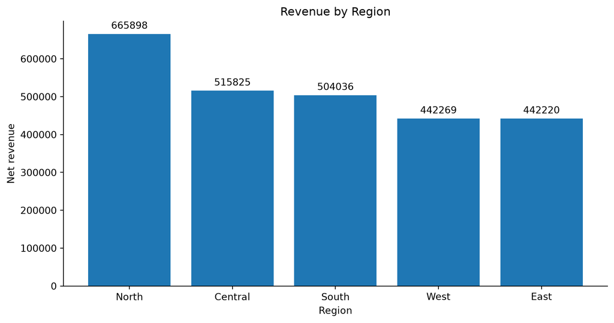

Net revenue by sales region

# Monthly Revenue Trend

The following analysis evaluates revenue distribution across months.

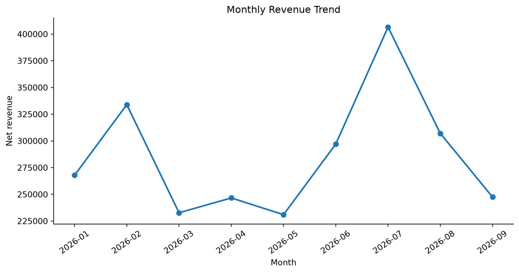

Monthly net revenue trend

## Monthly Revenue Table

| month | revenue |
| --- | --- |
| 2026-01 | 267,867.99 |
| 2026-02 | 333,930.89 |
| 2026-03 | 232,734.44 |
| 2026-04 | 246,626.45 |
| 2026-05 | 230,933.27 |
| 2026-06 | 297,097.19 |
| 2026-07 | 406,519.69 |
| 2026-08 | 307,060.60 |
| 2026-09 | 247,476.51 |

# Data Validation

The calculated transaction-level revenue must equal the aggregated regional revenue, within the permitted rounding tolerance.

| Validation check | Result |
| --- | --- |
| Transaction revenue | 2.57025e+06 |
| Regional revenue | 2.57025e+06 |
| Absolute difference | 0 |
| Missing revenue values | 0 |

# Methodology

## Extract

The raw `sales.csv` file is loaded using pandas.

## Transform

The pipeline performs:

- Column name normalization.
- Technical row removal.
- Duplicate removal.
- Numeric conversion.
- Missing discount replacement.
- Missing price recovery.
- Region name standardization.
- Virtual column calculations.

## Load

The processed results are aggregated by region and exported to:

`revenue_by_region.csv`

# Testing

Unit tests cover:

- Addition.
- Subtraction.
- Multiplication.
- Invalid expressions.
- Missing columns.
- Invalid column names.
- Numeric values.
- DataFrame immutability.
- Data cleaning.
- Revenue calculations.
- Regional aggregation.

Run the test suite:

```bash
python -m pytest -v
```

# Reproducibility

To reproduce the analysis, execute:

```bash
python pipeline.py
```

Generate the HTML report:

```bash
quarto render reports/sales_analysis.qmd --to html
```

Generate the PDF report:

```bash
quarto render reports/sales_analysis.qmd --to pdf
```

## Dependencies

- Python
- pandas
- matplotlib
- tabulate
- ipykernel
- pytest
- Quarto CLI
- LaTeX distribution for PDF generation

# Conclusion

This project demonstrates an end-to-end data processing workflow using Python and pandas.

The solution integrates:

- Custom DataFrame transformations.
- Data validation and cleaning.
- Revenue calculations.
- Automated testing.
- Regional and monthly analytics.
- Reproducible HTML and PDF reporting.

The analysis is based on the cleaned sales dataset and the existing ETL pipeline.